# Week 11: Display Interfacing

## Week 11

Display Interfacing: Character LCD and TFT Displays

## Why this week matters

- Visual feedback turns a sensor into an instrument
- Character LCDs are still useful for simple status and debug panels
- TFT displays make embedded systems feel like products, not demos
- Display selection directly impacts RAM, pins, SPI bandwidth, and CPU load
- Display bugs are usually visible, but the cause is often timing or protocol order

## Learning objectives

- Wire and drive an HD44780 character LCD through an I2C backpack
- Explain how the I2C backpack creates HD44780 4-bit nibble transfers
- Diagnose common character LCD address, wiring, contrast, and initialization failures
- Explain TFT pixels, RGB565 color format, and framebuffer size
- Describe the ST7789 command/data protocol over SPI
- Explain how bitmap fonts become pixel streams on a TFT
- Explain why TFT refresh usually needs high-speed SPI and DMA

## Agenda (90 minutes)

| Part | Time | Focus |
| --- | --- | --- |
| 1. HD44780 character LCD | 40 min | I2C backpack wiring, timing, initialization, driver flow |
| 2. TFT fundamentals | 15 min | TFT pixels, RGB565 color, frame size |
| 3. ST7789 over SPI | 25 min | Pin interface, drawing protocol, bitmap fonts, HAL/DMA concept |
| 4. Debugging checklist | 10 min | Common failure modes and what to measure |

# Part 1: Character LCD — HD44780

## HD44780 character LCD overview

- **The workhorse:** still common, cheap, and robust
- Text only — displays from internal CGROM (5x8 dot matrix per character)
- Up to 8 user-defined 5x8 glyphs in CGRAM (bar graphs, simple icons)
- Supply voltage: 2.7-5.5 V; logic often 5 V — check clones for 3.3 V tolerance
- Backlight: LED, typically 15-30 mA; check if series resistor is included
- Contrast: analog voltage on **V<sub>O</sub>** pin via 10 kΩ pot

**Common pitfall:** incorrect V<sub>O</sub> makes display appear blank or show solid blocks.

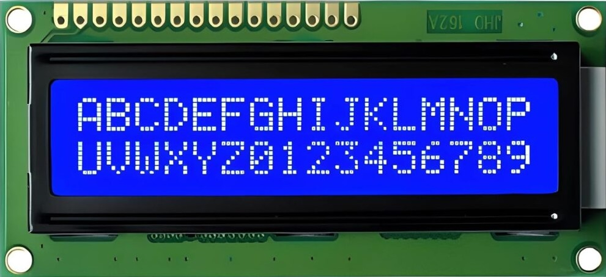

16x2 Character LCD

## HD44780: I2C backpack wiring

```
Nucleo Pin       | Backpack Pin | Function
-----------------|--------------|-----------------------
PB8 / D15        | SCL          | I2C1 clock
PB9 / D14        | SDA          | I2C1 data
GND              | GND          | Common ground
3V3 or 5V*       | VCC          | Backpack + LCD power
Pot on backpack  | VO           | Contrast adjustment
```

- Backpack usually uses **PCF8574** I/O expander
- Common address: `0x27`; some modules use `0x3F`
- Backpack drives RS, E, and D4-D7 internally
- If powered at 5 V, verify SDA/SCL voltage safety or use a level shifter

[figure not shown]

PCF8574 I2C backpack module

## HD44780 pins: what the backpack hides

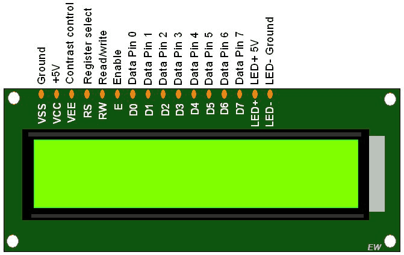

HD44780 pin functions

**LCD pins still matter**

The I2C backpack is soldered to the 16-pin LCD header and drives these LCD signals internally:

| LCD signal | Backpack role |
| --- | --- |
| RS | command/data select |
| E | latch each nibble |
| D4-D7 | 4-bit data bus |
| RW | usually tied low |
| VO | contrast pot |
| A/K | backlight power |

**Student wiring:** connect only `SDA`, `SCL`, `VCC`, and `GND` to the backpack.

## HD44780: critical timing

**The E (Enable) pulse still clocks data into the controller**

- Data is latched on the **falling edge** of E
- With the backpack, E is toggled by I2C writes to the PCF8574
- I2C is slower than the E minimum pulse width, but the LCD execution delay still matters
- Most commands: ~37 us execution time
- `ClearDisplay` and `ReturnHome`: ~1.53 ms — use `HAL_Delay(2)` after these

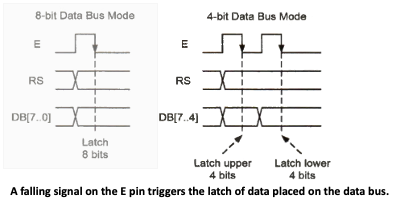

HD44780 Enable pulse timing

**Delay rule for this lab:**

Use fixed delays after writes; add `HAL_Delay(2)` after `ClearDisplay` and `ReturnHome`.

## HD44780: power-on initialization (4-bit mode)

[figure not shown]

HD44780 initialization flow

**Exact command sequence**

```
wait >15 ms after VDD valid

0x30, wait >4.1 ms
0x30, wait >100 us
0x30, wait >100 us

0x20  -> 4-bit mode
0x28  -> 4-bit, 2 lines, 5x8
0x08  -> display off
0x01  -> clear, wait >2 ms
0x06  -> increment cursor
0x0C  -> display on
```

**Key takeaway:** initialization is rigid. Miss one step and nothing works.

## HD44780: initialization code matches the flow

```c
extern I2C_HandleTypeDef hi2c1;
#define LCD_ADDR (0x27 << 1)   // try 0x3F if scanner finds it

static void lcd_write4(uint8_t nibble, bool is_data);
static void lcd_write4_raw(uint8_t nibble) {
    lcd_write4(nibble, false);  // command mode, one nibble only
}

void lcd_init(void) {
    HAL_Delay(20);                  // [1] VDD valid -> wait >15 ms

    lcd_write4_raw(0x03);           // [2] force known 8-bit startup state
    HAL_Delay(5);                   //     wait >4.1 ms
    lcd_write4_raw(0x03);
    HAL_Delay(1);                   //     wait >100 us
    lcd_write4_raw(0x03);
    HAL_Delay(1);                   //     wait >100 us

    lcd_write4_raw(0x02);           // [3] switch to 4-bit mode
    HAL_Delay(1);

    lcd_cmd(0x28);                  // [4] 4-bit, 2 lines, 5x8 font
    lcd_cmd(0x08);                  // [5] display off during setup
    lcd_cmd(0x01); HAL_Delay(2);    // [6] clear display: slow command
    lcd_cmd(0x06);                  // [7] cursor increments after write
    lcd_cmd(0x0C);                  // [8] display on, cursor off
}
```

**Connect code to the flow**

- `[1]` Power reaches valid V<sub>DD</sub>
- `[2]` Three startup sync nibbles over I2C
- `[3]` Enter 4-bit interface
- `[4]` Configure function
- `[5]` Disable display while configuring
- `[6]` Clear and wait long enough
- `[7]` Set cursor behavior
- `[8]` Turn display on

**Important:** `lcd_cmd()` works only after `[3]`, because full bytes now mean two I2C-backed nibble writes.

`lcd_cmd(x)` is the command wrapper: `lcd_send(x, false)`.

## HD44780: driver flow

[figure not shown]

HD44780 4-bit driver flow

```
send_byte(byte, mode):
    RS = mode          # data or command
    send upper nibble to backpack
    I2C write: E high then E low
    send lower nibble to backpack
    I2C write: E high then E low
    wait for LCD to finish

print string:
    for each character:
        send_byte(character, DATA)
```

**Key idea:** the LCD never receives an 8-bit byte at once in 4-bit mode.  
Every byte becomes two backpack writes, and each nibble is latched by an E pulse generated through I2C.

## HD44780: driver code matches the flow

```c
#define LCD_ADDR (0x27 << 1)
#define LCD_RS 0x01
#define LCD_E  0x04
#define LCD_BL 0x08

static void lcd_i2c_write(uint8_t v) {
    v |= LCD_BL;  // keep backlight on
    HAL_I2C_Master_Transmit(&hi2c1, LCD_ADDR, &v, 1, 10);
}

static void lcd_pulse(uint8_t v) {
    lcd_i2c_write(v | LCD_E);   // E high
    lcd_i2c_write(v & ~LCD_E);  // falling edge latches nibble
}

static void lcd_write4(uint8_t nibble, bool is_data) {
    uint8_t v = (nibble << 4) | (is_data ? LCD_RS : 0);
    lcd_pulse(v);
}

void lcd_send(uint8_t byte, bool is_data) {
    lcd_write4(byte >> 4, is_data);         // upper nibble first
    lcd_write4(byte & 0x0F, is_data);       // lower nibble second
    HAL_Delay(is_data ? 1 : 2);             // wait for LCD execution
}

void lcd_putc(char c) { lcd_send((uint8_t)c, true); }
void lcd_puts(const char *s) { while (*s) lcd_putc(*s++); }
```

**Connect code to the flow**

- `lcd_puts()` = **print string**
- `lcd_putc()` = **print one character**
- `lcd_send()` = **send byte**
- first `lcd_write4()` = **upper nibble to PCF8574**
- second `lcd_write4()` = **lower nibble to PCF8574**
- `lcd_pulse()` = **E high then low over I2C**
- final delay = **LCD executes internally**

**Backpack mapping:** common modules use P0=RS, P2=E, P3=backlight, P4-P7=D4-D7.

## HD44780: troubleshooting

| Symptom | Most likely cause | Fix |
| --- | --- | --- |
| Blank display | Contrast V<sub>O</sub> wrong | Adjust pot; check power |
| No response at all | Wrong I2C address | Run scanner; try `0x27` or `0x3F` |
| Scanner finds nothing | SDA/SCL swapped, no power, no pullups | Check wiring and voltage |
| Solid black blocks on top row | Contrast too low, init failed | Turn pot; verify init sequence |
| Garbled / ghost characters | Timing violation or backpack bit mapping mismatch | Check PCF8574 mapping |
| Display works once then freezes | Missing delay after ClearDisplay | Add `HAL_Delay(2)` after 0x01 |

**Tool of choice:** scope SCL/SDA first; if accessible, probe E on the backpack output.

# Part 2: Color TFT — ST7789 over SPI/DMA

## TFT LCD technology

- **TFT (Thin-Film Transistor):** active matrix LCD
  - Each pixel is controlled by its own transistor
  - Faster response and better contrast than passive LCDs
- **IPS (In-Plane Switching):**
  - Wide viewing angles
  - Vibrant color reproduction
- **Controller (ST7789):** built-in display RAM stores pixel data

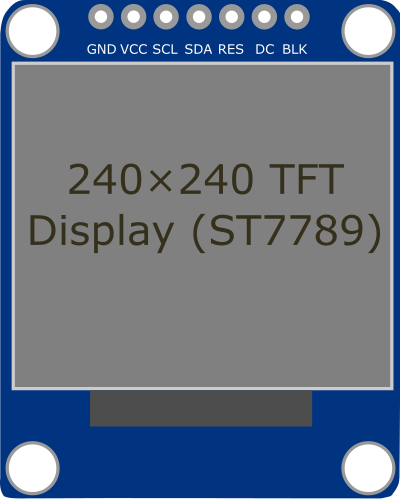

TFT module / structure

## Pixels & color format: RGB565

- **Resolution:** 240 x 240 grid
  - Total pixels: 57,600
- **Color depth:** 16-bit (65,536 colors)
- **RGB565 format:**
  - **Red:** 5 bits (32 shades)
  - **Green:** 6 bits (64 shades)
  - **Blue:** 5 bits (32 shades)
- Green gets 6 bits because human vision is most sensitive to green detail

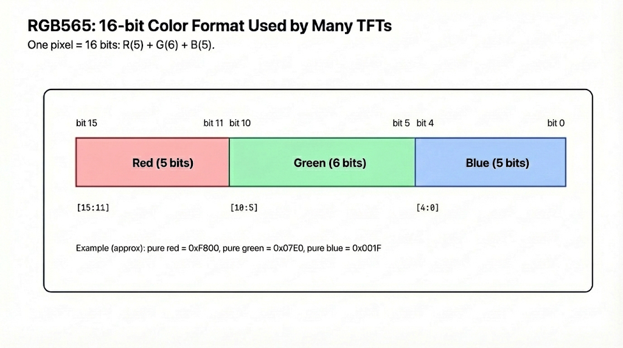

RGB565 memory layout

## Why SPI + DMA?

We use the **ST7789** TFT driver.

- **Bandwidth challenge:**
  - Resolution: 240 x 240 pixels
  - Color: 16-bit = 2 bytes per pixel
  - Frame size: $240 \times 240 \times 2 = 115,200$ bytes
- **For 30 FPS:**
  - Required traffic: $115,200 \times 30 \approx 3.5$ MB/s
  - Conclusion: use MHz-range SPI and DMA

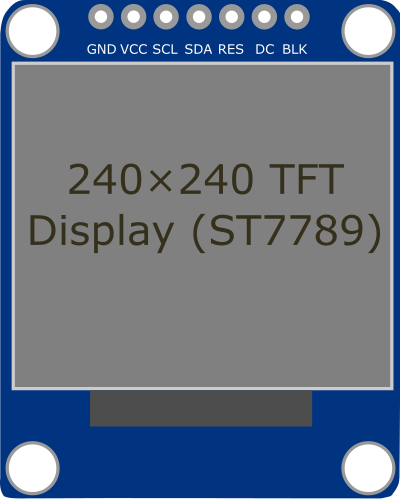

240x240 TFT module

## ST7789 pin interface

**Standard 4-wire SPI interface:**

1. **MOSI (SDA):** serial data, commands, and pixels
2. **SCK (SCL):** serial clock
3. **RES (RST):** hardware reset, active low
4. **DC (WR):** data/command selection
   - Low: command byte
   - High: data byte or pixel stream

**No MISO:** most small TFT modules are write-only in this lab setup.

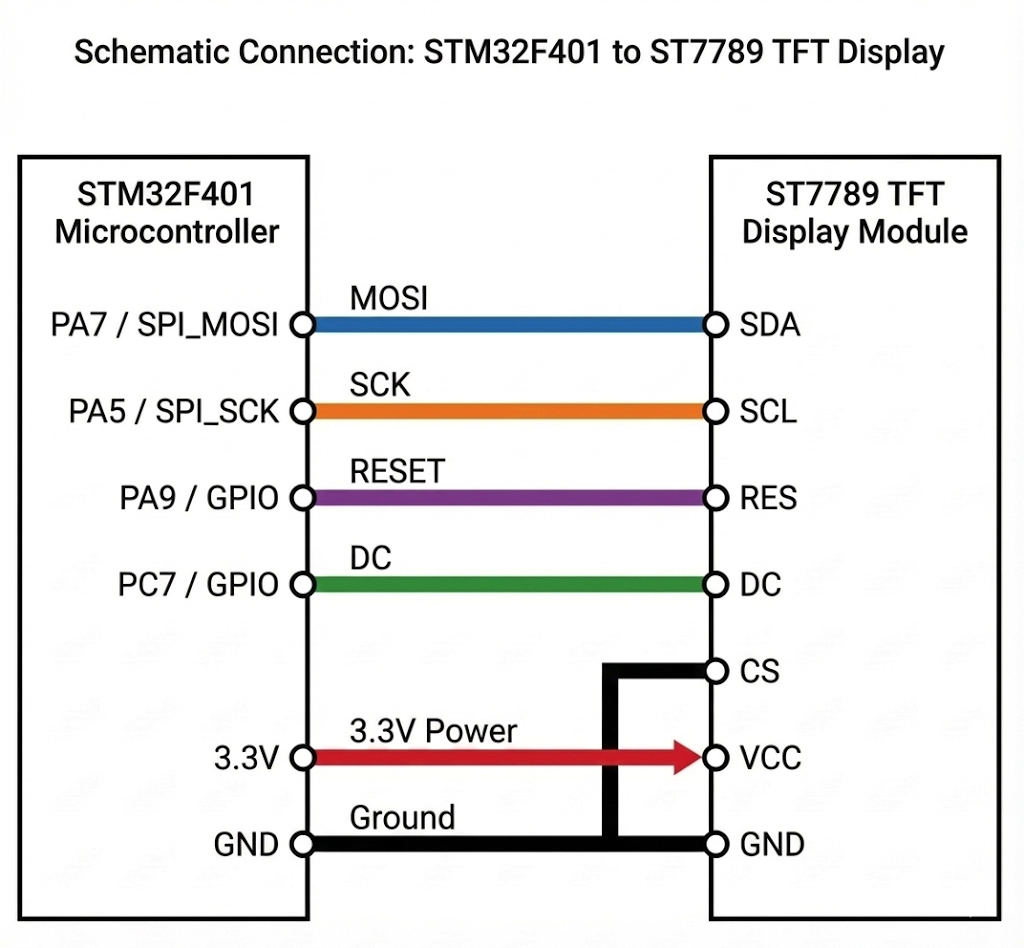

Interfacing STM32F401 with ST7789

## ST7789 drawing protocol

[figure not shown]

ST7789 drawing protocol flow

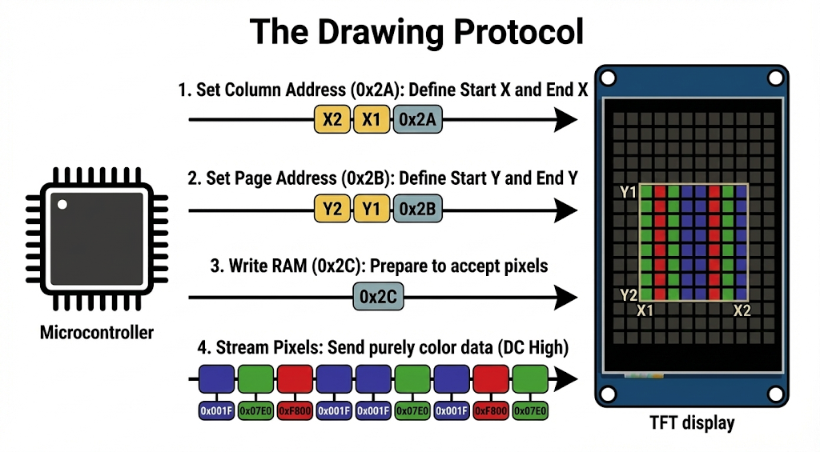

Window and pixels concept

## ST7789 driver layers: what the library hides

| Public call | Driver work underneath |
| --- | --- |
| `ST7789_Init()` | reset, sleep out, set RGB565, display on |
| `ST7789_FillScreen(color)` | call `FillRect()` for 240 x 240 |
| `ST7789_FillRect(x,y,w,h,color)` | set window, stream repeated RGB565 pixels |
| `ST7789_WriteString(...)` | draw characters one bitmap at a time |

**Mental model:** application code requests shapes/text; the driver converts that request into command bytes, address windows, and pixel bytes.

```
application
  ST7789_WriteString()
  ST7789_FillRect()

driver API
  SetWindow()
  WriteCommand()
  WriteData()

hardware transfer
  DC pin selects command/data
  SPI sends bytes
  DMA moves pixel buffers

display controller
  GRAM stores pixels
```

## Bitmap fonts: a letter is just a pixel mask

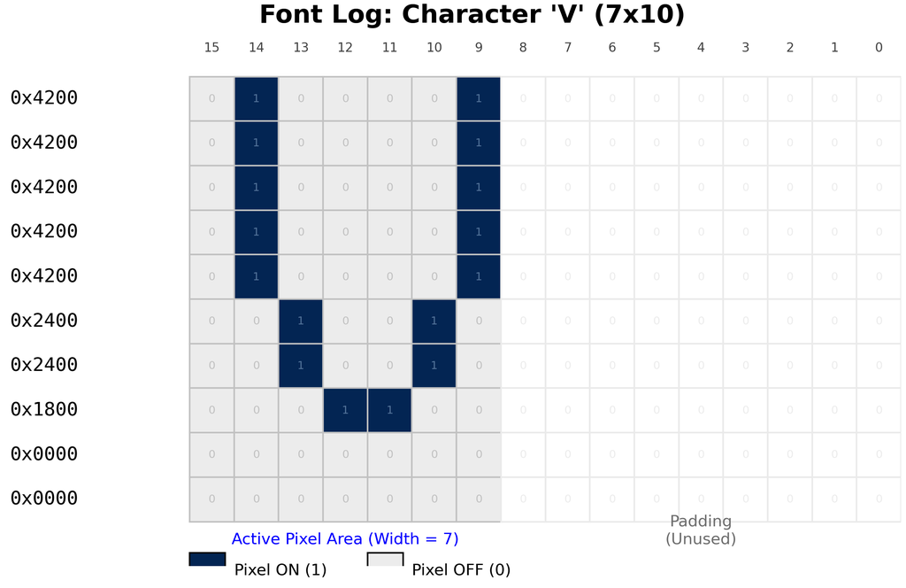

7x10 font bitmap example

- A font stores each character as a small bitmap
- Example: `Font_7x10` means 7 columns x 10 rows
- Each row is stored as bits inside a `uint16_t`
- A `1` bit means draw foreground color
- A `0` bit means draw background color
- Text drawing is repeated pixel drawing

**Memory point:** fonts live in Flash; only the active pixel stream uses RAM.

## Font data structure: font descriptor + row table

```c
typedef struct {
    const uint8_t width;       // pixels per character row
    const uint8_t height;      // rows per character
    const uint16_t *data;      // all character rows
} FontDef;

static const uint16_t Font7x10_Table[] = {
    // ASCII 32: ' ' -> 10 rows
    0x0000, 0x0000, /* ... */

    // ASCII 33: '!' -> next 10 rows
    0x0C00, 0x0C00, /* ... */
};

FontDef Font_7x10 = {
    7,                 // width
    10,                // height
    Font7x10_Table     // pointer to the row table
};
```

**What is stored where?**

- `FontDef` describes the **whole font**
- One character is **not** a separate struct
- Characters are stored sequentially in `Font7x10_Table`
- For `Font_7x10`, each character uses 10 `uint16_t` rows
- ASCII space starts at index 0
- ASCII `!` starts after 10 rows

**Offset formula**

```c
char_offset = (ch - 32) * font.height;
```

## Bitmap-to-pixel code: one character

```c
void ST7789_WriteChar(uint16_t x, uint16_t y, char ch,
                      FontDef font, uint16_t fg, uint16_t bg) {
    uint32_t char_offset = (ch - 32) * font.height;

    SetWindow(x, y, x + font.width - 1, y + font.height - 1);
    DC_HIGH();                       // following bytes are pixel data

    for (uint32_t row = 0; row < font.height; row++) {
        uint16_t bits = font.data[char_offset + row];

        for (uint32_t col = 0; col < font.width; col++) {
            uint16_t color =
                ((bits << col) & 0x8000) ? fg : bg;

            uint8_t px[2] = { color >> 8, color & 0xFF };
            HAL_SPI_Transmit(&hspi1, px, 2, HAL_MAX_DELAY);
        }
    }
}
```

**Connect code to bitmap**

- `char_offset` selects the character
- `row` selects one bitmap row
- `col` tests one bit in that row
- bit = 1 -> foreground RGB565
- bit = 0 -> background RGB565
- each pixel becomes two SPI bytes

**Why it works:** the ST7789 auto-increments inside the active address window.

## Wiring: Nucleo to ST7789 TFT

[output not shown]

**Note:** PA6 (MISO) is not used because the display is write-only in this setup.

## ST7789 HAL/DMA concept

```c
// 1. Set window: command 0x2A = column address
uint8_t cmd = 0x2A;
HAL_GPIO_WritePin(DC_PORT, DC_PIN, GPIO_PIN_RESET); // command
HAL_SPI_Transmit(&hspi1, &cmd, 1, 10);

// Coordinates are 16-bit: start MSB/LSB, end MSB/LSB
uint8_t params[] = {
    x0 >> 8, x0 & 0xFF,
    x1 >> 8, x1 & 0xFF
};
HAL_GPIO_WritePin(DC_PORT, DC_PIN, GPIO_PIN_SET);   // data
HAL_SPI_Transmit(&hspi1, params, 4, 10);

// 2. Write RAM command and start DMA pixel transfer
cmd = 0x2C;
HAL_GPIO_WritePin(DC_PORT, DC_PIN, GPIO_PIN_RESET);
HAL_SPI_Transmit(&hspi1, &cmd, 1, 10);

HAL_GPIO_WritePin(DC_PORT, DC_PIN, GPIO_PIN_SET);
HAL_SPI_Transmit_DMA(&hspi1, pixel_buffer, buffer_size);
```

- Do not access the same SPI peripheral while DMA is busy
- Wait for transfer-complete callback or check `hspi1.State`

## Driver internals: rectangle fill with DMA chunks

```c
void ST7789_FillRect(uint16_t x, uint16_t y,
                     uint16_t w, uint16_t h, uint16_t color) {
    SetWindow(x, y, x + w - 1, y + h - 1);

    static uint8_t buf[512];         // 256 RGB565 pixels
    uint8_t hi = color >> 8;
    uint8_t lo = color & 0xFF;

    for (int i = 0; i < 256; i++) {
        buf[2*i]     = hi;           // RGB565 high byte
        buf[2*i + 1] = lo;           // RGB565 low byte
    }

    uint32_t remaining = (uint32_t)w * h;
    DC_HIGH();                       // following bytes are pixels

    while (remaining > 0) {
        uint16_t n = (remaining > 256) ? 256 : remaining;
        spi_tx_done = 0;
        HAL_SPI_Transmit_DMA(&hspi1, buf, n * 2);
        while (!spi_tx_done) { }     // simple, but CPU blocks here
        remaining -= n;
    }
}
```

**Why chunking matters**

- Full frame: 115,200 bytes
- STM32F401RE SRAM: 96 KB
- A full framebuffer does not fit comfortably
- A 512-byte chunk is reusable
- DMA moves the chunk to SPI
- Callback sets `spi_tx_done = 1`

**Design tradeoff:** simple chunking saves RAM, but the wait loop still blocks the CPU.

## TFT failure modes and checks

| Symptom | Likely cause | What to check |
| --- | --- | --- |
| White/blank screen | Init sequence missing or reset wrong | RES timing, `Sleep Out`, `Display On` |
| Random colors | Wrong RGB565 byte order | Pixel buffer endianness |
| Nothing changes | DC/CS wiring wrong | Scope DC, CS, SCK, MOSI |
| Partial image shifted | Wrong address window | `0x2A`, `0x2B` parameters |
| MCU stalls | Blocking full-screen SPI writes | DMA use and callback handling |

**Measurement evidence:** capture SCK/MOSI/DC during one window update and measure transfer time.

## Summary

**Two display families, two mental models:**

|  | HD44780 character LCD | ST7789 TFT |
| --- | --- | --- |
| Data unit | Character code / command | RGB565 pixel data / command |
| Interface | I2C backpack -> 4-bit HD44780 | SPI + DC/RES |
| MCU RAM pressure | Very low | High for full frames |
| Timing risk | Enable pulse + command delays | SPI bandwidth + DMA state |
| Best for | Status text | Color UI, graphs |

**What to remember:**

1. HD44780 bytes become two I2C-backed nibble transfers.
2. TFT frames are large: 240 x 240 x 2 = 115,200 bytes.
3. ST7789 drawing is command window first, pixel stream second.
4. DMA is what keeps TFT refresh from blocking the firmware.